# Cross-section Integration: Human Kidney

# Overview

This R Markdown document runs a **DaVinci** cross-section integration workflow on KPMP Visium datasets. It covers:

1. Reading a mapping table to define dataset identifiers (`dataset.opts`), loading the count matrix + spatial coordinates and preprocessing
2. Running `Horizontal.Integration.Assemble()` for cross-section integration
3. Clustering and visualizing niches across sections with aspect-ratio-aware plotting

Update paths and parameters to match your local setup.

## Setup

Load packages and set the working directory. Make sure the `data/` folder exists under this directory (or adjust paths accordingly).

```r
library(DaVinci)
library(ggpubr)

setwd("~/For_Tutorial/KPMP/")
```

## Configuration

`normalize.version` controls preprocessing. Use `"gene"` for transcriptomics, or `"LSI_*"` modes for ATAC-like inputs.

```r
normalize.version <- "gene"  # options: "gene", "LSI_1", "LSI_2", "LSI_3"
```

## Define datasets (KPMP mapping)

We read a mapping table (TSV) and derive a set of dataset IDs that match the naming scheme of the RDS files in `data.dir`. Several entries are renamed for convenience/consistency.

```r
data.dir <- "~/For_Tutorial/KPMP/data/"

pData <- read.csv(paste0(data.dir, "mapping.tsv"), header = TRUE, sep = "\t")

dataset.opts <- pData$Patient.ID..highlighed.if.multiome.or.scRNA.seq.is.available.
dataset.opts[dataset.opts == "IU-F52"] <- "F52"
dataset.opts[dataset.opts == "IU-F59"] <- "F59"
dataset.opts[dataset.opts == "IU-M32"] <- "M32"
dataset.opts[dataset.opts == "IU-M61"] <- "M61"

dataset.opts[pData$Internal.ID..Visium. == "V10S14-086_XY03_21-0063"] <- "28-12265_1"
dataset.opts[pData$Internal.ID..Visium. == "V10S14-087_XY02_21-0063"] <- "28-12265"
```

## Load and preprocess each dataset

Each dataset is stored as `data.dir/<dataset>.RDS`, containing at least: - `mat`: gene-by-spot raw counts matrix - `coor`: spot-by-(x,y) coordinate matrix

We preprocess each section and store: - `Y.list`: processed data matrix per section - `L.list`: spatial Laplacian per sample (as returned by `preprocess()`) - `coor.list`: coordinate matrix per section

```r
Y.list <- list()
L.list <- list()
coor.list <- list()

for (ii in seq_along(dataset.opts)) {
  input.file <- paste0(data.dir, dataset.opts[ii], ".RDS")
  input <- readRDS(input.file)

  mat <- input$mat
  coor <- input$coor

  if (normalize.version == "gene") {
    fin <- preprocess(mat, coor, type = "rna", graph.opt = "Tri.mesh", frac.thr = 0.95)
  } else if (normalize.version == "LSI_1") {
    fin <- preprocess(mat, coor, type = "atac", graph.opt = "Tri.mesh",
                      LSI.method = "1", LSI.scale.factor = 1e5, LSI.peak.filter.thr = 0.95)
  } else if (normalize.version == "LSI_2") {
    fin <- preprocess(mat, coor, type = "atac", graph.opt = "Tri.mesh",
                      LSI.method = "2", LSI.scale.factor = 1e5, LSI.peak.filter.thr = 0.95)
  } else if (normalize.version == "LSI_3") {
    fin <- preprocess(mat, coor, type = "atac", graph.opt = "Tri.mesh",
                      LSI.method = "3", LSI.scale.factor = 1e5, LSI.peak.filter.thr = 0.95)
  }

  Y.list[[ii]] <- fin$mat
  L.list[[ii]] <- fin$L
  coor.list[[ii]] <- fin$coor
}
```

## Cross-section integration

This step infers robust latent variables per section and integrates them across sections. The key tuning parameter is `k.arg.list`, a set of candidate numbers of latent variables to consider. **Note:** The wrapper function `Horizontal.Integration.Assemble` is readily parallelizable and will be implemented in a future release.

```r
ptm <- proc.time()
HI.res <- Horizontal.Integration.Assemble(
  dataset.opts = dataset.opts,
  Y.list  = Y.list,
  L.list  = L.list,
  coor.list = coor.list,
  k.arg.list = c(4, 6, 8, 10, 11, 12, 13, 15, 16, 18, 20, 22, 24)
)
print(proc.time() - ptm)
```

```
##      user    system   elapsed
## 50421.417  1444.714 51866.920
```

```r
#Feel free to save the integration result for later reuse.
#saveRDS(HI.res, file = "output/HI.res.RDS")
```

## Clustering the integrated latent variables

We cluster the integrated representation `HI.res$mat`. The workflow is:

```r
mat <- HI.res$mat
mat.slice.id <- HI.res$mat.slice.id



snn.res <- Seurat::FindNeighbors(
  DaVinci:::L2Norm(mat, MARGIN = 2),
  k.param = 40,
  return.neighbor = FALSE,
  compute.SNN = TRUE,
  verbose = FALSE
)

#singleton clusters will be handled implicitly and merged based on the similarity calculated from DaVinci:::L2Norm(mat, MARGIN = 2)
p.res <- leiden_adaptive(
  snn.res$snn,
  num.of.cluster = 10,
  resolution.start = 0.4,
  adaptive.size = 2,
  method = "louvain",
  full = TRUE,
  remove.singleton = DaVinci:::L2Norm(mat, MARGIN = 2)
)
```

```
## 0.6 0.4 0.8
```

## Merge singleton / adjust cluster labels (optional)

```r
partition <- p.res$partition
names(partition) <- rownames(mat)
```

## Visualization of integrated niches

We load a stored aspect ratio object (to respect slice-specific scaling), then use `scatter.DiscretePlot.list()` to visualize cluster assignments across samples. The result is a list of ggplot objects that can be arranged into a multi-panel figure.

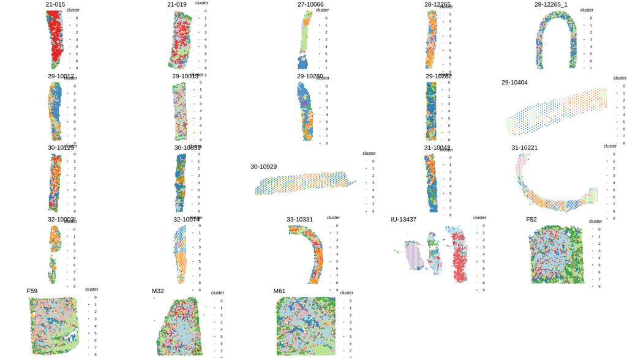

```r
ratio.plot <- readRDS(paste0(data.dir, "aspect_ratio.RDS"))
ratio.plot <- ratio.plot[dataset.opts]

par.to_plot <- partition
names(coor.list) <- dataset.opts

plot.list <- scatter.DiscretePlot.list(
  par.to_plot,
  coor.list,
  mat.slice.id,
  dataset.opts,
  pt.size = 0.5,
  title.size = 15,
  orientation = "x-y",
  ratio = ratio.plot,
  return.obj = TRUE
)

ggarrange(plotlist = plot.list)
```